# Analysis of RNA-seq data in R and Bioconductor

Rockefeller University, Bioinformatics Resource Centre

http://rockefelleruniversity.github.io/RU_RNAseq/

## The data.

In this session we will be reviewing data from Christina Leslie’s lab at MSKCC on T-Reg cells and activated T-Reg cells. T-Reg data can be found on the Encode portal [here](https://www.encodeproject.org/experiments/ENCSR486LMB/) and activated T-Reg data [here](https://www.encodeproject.org/experiments/ENCSR726DNP/)

I have aligned all FQ to BAM and counted in genes and exons using Rsubread and summariseOverlaps().

I have also quantified our transcripts from FQ files using our transcript fasta from last session and Salmon.

## What we will cover.

In our last session we will looked at two separate ways we can gain gene expression estimates from raw sequencing data as fastQ files.

In this session we will import our expression estimates to identify differences in the expression of genes between conditions.

## Counts from SummariseOverlaps

With this BamFileList I can count as we did a single sample to produce our **RangedSummarizedExperiment** object of counts in genes across all samples.

```r
library(TxDb.Mmusculus.UCSC.mm10.knownGene)
library(GenomicAlignments)
geneExons <- exonsBy(TxDb.Mmusculus.UCSC.mm10.knownGene,by="gene")
geneCounts <- summarizeOverlaps(geneExons,myBams,
                                    ignore.strand = TRUE)
geneCounts
```

```
## class: RangedSummarizedExperiment
## dim: 24100 5
## metadata(0):
## assays(1): ''
## rownames(24100): 497097 19888 ... 100040911 170942
## rowData names(0):
## colnames(5): Sorted_T_reg_1 Sorted_T_reg_2 Sorted_T_reg_act_1
##   Sorted_T_reg_act_2 Sorted_T_reg_act_3
## colData names(0):
```

## Speeding up SummariseOverlaps

We can control the parallisation in BiocParallel often choosing either a serial mode (no parallisation) with **SerialParam()** function or the number of cores to use with **MulticoreParam(workers=NUMBEROFCORES)**.

We use the **register()** function to set the desired parallelisation.

```r
paramMulti <- MulticoreParam(workers=2)
paramSerial <- SerialParam()
register(paramSerial)
```

## Counts from SummariseOverlaps

We can retrieve the GRangesList we counted by the **rowRanges()** accessor function.

Each GRangesList element contains exons used in counting, has Entrez gene ID and is in matching order as rows in our count table.

```r
rowRanges(geneCounts)[1:2,]
```

```
## GRangesList object of length 2:
## $497097
## GRanges object with 3 ranges and 2 metadata columns:
##       seqnames             ranges strand |   exon_id   exon_name
##          <Rle>          <IRanges>  <Rle> | <integer> <character>
##   [1]     chr1 [3214482, 3216968]      - |      8008        <NA>
##   [2]     chr1 [3421702, 3421901]      - |      8009        <NA>
##   [3]     chr1 [3670552, 3671498]      - |      8012        <NA>
##
## $19888
## GRanges object with 6 ranges and 2 metadata columns:
##       seqnames             ranges strand | exon_id exon_name
##   [1]     chr1 [4290846, 4293012]      - |    8013      <NA>
##   [2]     chr1 [4343507, 4350091]      - |    8014      <NA>
##   [3]     chr1 [4351910, 4352081]      - |    8015      <NA>
##   [4]     chr1 [4352202, 4352837]      - |    8016      <NA>
##   [5]     chr1 [4360200, 4360314]      - |    8017      <NA>
##   [6]     chr1 [4409170, 4409241]      - |    8018      <NA>
##
## -------
## seqinfo: 66 sequences (1 circular) from mm10 genome
```

## Log transform or as counts.

Two broadly different approaches to RNAseq analysis could be.

- Log2 transform, normalise, use standard test for normal distribution to find differential expression.
- Normalise and use test suitable for count data to find differential expression.

## DESeq2

Although options for differential expression are available in R including DESeq2, EdgeR and Voom/Limma.

Both EdgeR and DESeq2 works with unnormalised/non-transformed countdata to detect differential expression.

Voom transforms count data into log2 transformed values with associated mean dependent weighting for use in Limma differential expression functions.

We will use the DESeq2 software to identify differential expression.

## DESeq2

Previously we have been using **DESeqDataSetFromMatrix()** constructor.

We must provide the counts matrix, our metadata dataframe, our design specifying with metadata columns to test and a GRanges we counted on.

```r
countMatrix <- assay(geneCounts)
countGRanges <- rowRanges(geneCounts)
dds <- DESeqDataSetFromMatrix(countMatrix,
                              colData = metaData,
                              design = ~Group,
                              rowRanges=countGRanges)
dds
```

```
## class: DESeqDataSet
## dim: 24100 5
## metadata(1): version
## assays(1): counts
## rownames(24100): 497097 19888 ... 100040911 170942
## rowData names(0):
## colnames(5): Sorted_T_reg_1 Sorted_T_reg_2 Sorted_T_reg_act_1
##   Sorted_T_reg_act_2 Sorted_T_reg_act_3
## colData names(1): Group
```

## DESeq2

Now we can make use of the **DESeqDataSet()** function to build directly from our **RangedSummarizedExperiment** object.

We simply have to specify the **design** parameter to specify metadata column to test on.

```r
dds <- DESeqDataSet(geneCounts,design = ~Group)
```

```
## renaming the first element in assays to 'counts'
```

```r
dds
```

```
## class: DESeqDataSet
## dim: 24100 5
## metadata(1): version
## assays(1): counts
## rownames(24100): 497097 19888 ... 100040911 170942
## rowData names(0):
## colnames(5): Sorted_T_reg_1 Sorted_T_reg_2 Sorted_T_reg_act_1
##   Sorted_T_reg_act_2 Sorted_T_reg_act_3
## colData names(1): Group
```

## DESeq function

In its first step the **DEseq()** function normalises our data by evaluating the median expression of genes across all samples to produce a per sample normalisation factor (library size).

We can retrieve normalised and unnormalised values from our DESeq2 object using the **counts()** function and specifying the **normalized** parameter as TRUE. Normalised counts are counts divided by the the calculated library size.

```r
normCounts  <- counts(dds,normalized=TRUE)
normCounts[1:2,]
```

```
##        Sorted_T_reg_1 Sorted_T_reg_2 Sorted_T_reg_act_1 Sorted_T_reg_act_2
## 497097              0      0.9202987                  0                  0
## 19888               0      0.0000000                  0                  0
##        Sorted_T_reg_act_3
## 497097            0.00000
## 19888            10.12247
```

## DESeq results

Finally we can extract our contrast of interest using the **results()** function.

We must specify the **contrast** parameter, listing the metadata column of interest and the two groups to compare.

The resulting **DESeqResults** can be sorted by pvalue to list most significant changes at top of table.

```r
myRes <-results(dds,contrast = c("Group","Act","Naive"))
myRes <- myRes[order(myRes$pvalue),]
myRes[1:3,]
```

```
## log2 fold change (MLE): Group Act vs Naive
## Wald test p-value: Group Act vs Naive
## DataFrame with 3 rows and 6 columns
##        baseMean log2FoldChange      lfcSE      stat    pvalue      padj
##       <numeric>      <numeric>  <numeric> <numeric> <numeric> <numeric>
## 54167 20595.525       2.224160 0.05133798  43.32388         0         0
## 20198  4896.288       3.417348 0.07823816  43.67879         0         0
## 20200  6444.617       3.196367 0.07482242  42.71938         0         0
```

## DESeqResults objects

With our DESeqResults object We can get a very quick overview of differential expression changes using the **summary** function.

```r
summary(myRes)
```

```
##
## out of 19776 with nonzero total read count
## adjusted p-value < 0.1
## LFC > 0 (up)     : 2819, 14%
## LFC < 0 (down)   : 2373, 12%
## outliers [1]     : 0, 0%
## low counts [2]   : 6443, 33%
## (mean count < 6)
## [1] see 'cooksCutoff' argument of ?results
## [2] see 'independentFiltering' argument of ?results
```

## DESeqResults objects

We downweight genes with high fold change but low significance by using the **lfcShrink()** function as we have the **results()** function. This allows us to know use the log2FC as a measure of significance of change in our ranking for analysis and in programs such as **GSEA**.

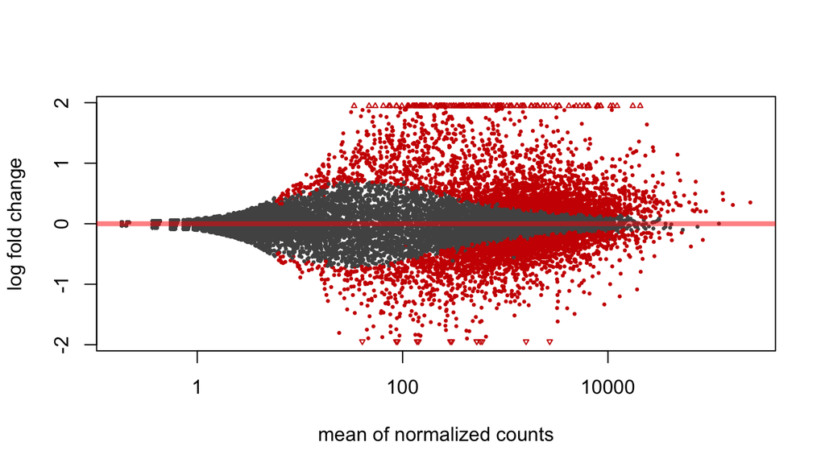

```r
myRes <-results(dds,contrast = c("Group","Act","Naive"))
myRes$log2FoldChange <- lfcShrink(dds,contrast = c("Group","Act","Naive"))
plotMA(myRes)
```

## DESeqResults objects - NA in padj

By default DEseq2 filters out low expressed genes to assist in multiple testing correction. This results in **NA** values in **padj** column for low expressed genes.

```r
table(is.na(myResAsDF$padj))
```

```
##
## FALSE  TRUE
## 13333 10767
```

## DESeqResults objects - NA in padj

Typcially genes with **NA** padj values should be filtered from the table for later evaluation and functional testing.

```r
myResAsDF <- myResAsDF[!is.na(myResAsDF$padj),]
myResAsDF[1:3,]
```

```
##        baseMean log2FoldChange      lfcSE      stat      pvalue       padj
## 27395 1935.3720     0.10189249 0.09277932 1.0982242 0.272106623 0.44505772
## 18777 4866.0229     0.26476382 0.10264730 2.5793549 0.009898504 0.03225238
## 21399  909.5543     0.06413133 0.12832937 0.4997401 0.617258080 0.76315857
##       newPadj
## 27395       1
## 18777       1
## 21399       1
```

## Tximport

The tximport package, written by same author as DESeq2, offers functions to import data from a wide range of transcript counting and quantification softwares and summarise transcript expression to genes.

We can first load the Bioconductor tximport package.

```r
library(tximport)
```

## Tximport

We can now use the **select()** function to retrieve a transcript names (TXNAME) to gene ids (GENEID) map from our TxDb.Mmusculus.UCSC.mm10.knownGene object.

Remember that available columns and keys can be found using the **columns()** and **keytype** functions respectively.

```r
Tx2Gene <- select(TxDb.Mmusculus.UCSC.mm10.knownGene,
                  keys = as.vector(temp[,1]),
                  keytype = "TXNAME",
                  columns = c("TXNAME","GENEID"))
Tx2Gene[1:10,]
```

```
##        TXNAME GENEID
## 1  uc007afg.1  18777
## 2  uc007afh.1  18777
## 3  uc007afi.2  21399
## 4  uc011wht.1  21399
## 5  uc011whu.1  21399
## 6  uc007afm.2 108664
## 7  uc007afn.2 108664
## 8  uc057atz.1 108664
## 9  uc007afo.2  18387
## 10 uc057aua.1  18387
```

## Tximport

The result from tximport is a list containing our summarised gene expression estimates

**Abundance** - Number Transcripts per million transcripts.(TPM) **Counts** - Estimated counts.

```r
salmonCounts$abundance[1:2,]
```

```
##              [,1]     [,2]     [,3]     [,4]     [,5]
## 100009600 0.04081 0.284574 0.122006 0.121766 0.141885
## 100009609 0.00000 0.000000 0.000000 0.000000 0.000000
```

```r
salmonCounts$counts[1:2,]
```

```
##              [,1]    [,2]    [,3]    [,4]    [,5]
## 100009600 1.52803 10.8942 4.35698 4.58801 6.04108
## 100009609 0.00000  0.0000 0.00000 0.00000 0.00000
```

## DESeq2 from Tximport

We can then proceed as we did for previous analysis using summarizeOverlaps counts.

```r
ddsSalmon <- DESeq(ddsSalmon)
myResS <-results(ddsSalmon,contrast = c("Group","Act","Naive"))
myResS <- myResS[order(myResS$pvalue),]
myResS[1:3,]
```

```
## log2 fold change (MLE): Group Act vs Naive
## Wald test p-value: Group Act vs Naive
## DataFrame with 3 rows and 6 columns
##         baseMean log2FoldChange      lfcSE      stat    pvalue      padj
##        <numeric>      <numeric>  <numeric> <numeric> <numeric> <numeric>
## 110454 20097.861       2.821459 0.05714341  49.37506         0         0
## 12772   8772.359       3.988465 0.09088340  43.88551         0         0
## 14939   6161.363       5.749023 0.10304817  55.78966         0         0
```

## Annotation of results table.

By whatever method we have chose to analyse of differential expression we will want to add some sensible gene names or symbols to our data frame of results.

We can use the **org.db** packages to retrieve Gene Symbols for our Entrez ids using the **select** function. Here we use the **org.db** package for mouse, **org.db**

```r
library(org.Mm.eg.db)
eToSym <- select(org.Mm.eg.db,
                 keys = rownames(myResAsDF),
                 keytype = "ENTREZID",
                 columns="SYMBOL")
eToSym[1:10,]
```

```
##    ENTREZID  SYMBOL
## 1     27395  Mrpl15
## 2     18777  Lypla1
## 3     21399   Tcea1
## 4    108664 Atp6v1h
## 5     12421  Rb1cc1
## 6    319263  Pcmtd1
## 7     71096   Sntg1
## 8     59014    Rrs1
## 9     76187  Adhfe1
## 10    17864   Mybl1
```

## Functional Enrichment analysis.

Following differential analysis it is a common step to identify any changes in groups of genes sharing a common biological function.

We can use the GOseq package to identify any functional enrichment in our differentially expressed genes.

The GOseq package requires a named vector of 1s or 0s indicating whether a gene is upregulated/downregulated.

```r
UpInAct <- annotatedRes$padj < 0.05 &
             annotatedRes$log2FoldChange > 0
UpInAct <- as.integer(UpInAct)
names(UpInAct) <- annotatedRes$ENTREZID
table(UpInAct)
```

```
## UpInAct
##     0     1
## 10883  2450
```

## Functional Enrichment analysis.

Having corrected for any bias we can now use the **goseq** function to for enrichment of GO or KEGG terms.

We must specify the genome build and ID we are using (here matching our TxDb.UCSC.**mm10**.**knownGene**.db) and the categories we wish to test (GO:BP,GO:MF,GO:CC,KEGG).

Here we identify the top enriched functional terms in GO biological processes.

```r
GO_UpInAct <- goseq(pwf,"mm10","knownGene",
                       test.cats=c("GO:BP"))
GO_UpInAct[1:3,]
```

```
##        category over_represented_pvalue under_represented_pvalue
## 605  GO:0002376            2.903329e-39                        1
## 6783 GO:0044699            1.133355e-34                        1
## 1752 GO:0006955            1.512886e-33                        1
##      numDEInCat numInCat                    term ontology
## 605         491     1539   immune system process       BP
## 6783       1756     7940 single-organism process       BP
## 1752        299      827         immune response       BP
```

## Retrieving function groups.

We can retrieve the genes in the **immune response (GO:0006955)** functional group using the** select** and the **org.Mm.eg.db** object.

```r
IRG_Entrez <- unique(ImmuneResponseGenes$ENTREZID)
IRG_Res <-  annotatedRes[annotatedRes$ENTREZID %in% IRG_Entrez,]
write.table(IRG_Res,
            file="ImmuneResponseGeneTable.csv",sep=",",
            row.names = FALSE)
```

# Time for an exercise.

Link_to_exercises

Link_to_answers